# Practical Machine Learning - Project

Pius M. Kirrmann

Thursday, August 21, 2014

# 1. Introduction

In this document we show how to apply the prediction tool *Random Forrest* to a data set obtained from weight lifting exercises. This dataset contains more than 100 attributes.  
After cleaning the dataset, we take a 60% training sample to build a model using the *Random Forrest* method. We perform cross-validation by applying the model to predict the values of the 40% testing sample.

The data set can be downloaded from http://groupware.les.inf.puc-rio.br/har  
We thank the authors for making this data set available to the public:

Velloso, E.; Bulling, A.; Gellersen, H.; Ugulino, W.; Fuks, H. Qualitative Activity Recognition of Weight Lifting Exercises. Proceedings of 4th International Conference in Cooperation with SIGCHI (Augmented Human ’13) . Stuttgart, Germany: ACM SIGCHI, 2013.

# 2. Data Cleaning

The data set has to be pre-processed since it does not meet the criteria for a tidy data set (http://vita.had.co.nz/papers/tidy-data.pdf). For example, there are a lot of NAs, some errors like DIV/0 and sparse columns. Our steps of pre-processing are explained in the R-code below.  
Please note that the target variable which we want to predict is called *classe*. It is in the last column of the data set. All other variables can be used as predicors.

```r
# Read training and test data (stored in the working directory)
trainingPML <- read.csv("pml-training.csv")
testingPML <- read.csv("pml-testing.csv")
# Clean training data set.
# Rows with new_window = 'yes' contain DIV/0 errors. We don't use them.
nw_ind <- which(trainingPML$new_window=="yes")
trainingPML <- trainingPML[-nw_ind,]
# Throw away all columns with NA's and all sparse columns.
# This can be done by visual inspection. Upload the data into a spreadsheet and
# remove all columns that do not contain tidy data.
# We also remove the timestamps.
# Call the names-function   names(trainingPML)   to get the indices of the
# columns to be removed. Put these into an index-vector:
indTidy <- c(2,8:11,37:49,61:68,84:86,102,113:124,140,151:160)
# Reduce training/testing data set
trainingPML0 <- trainingPML[,indTidy]
testingPML0 <- testingPML[,indTidy]
# Coerce user_name to numeric
trainingPML0$user_name <- as.numeric(trainingPML0$user_name)
testingPML0$user_name <- as.numeric(testingPML0$user_name)
```

There are more sophisticated methods in pre-processing, see for example  
https://topepo.github.io/caret/preprocess.html  
After playing around with different pre-processing and prediction methods, we found that for our purpose, these pre-processing steps are not necessary.

# 3. Training Phase

According to the cross-validation procedure, we take a portion of the data set as training set to build the model. We rely on the 60/40 rule of thumb, i.e. we take a 60% for training and keep the other portion for cross-validation. This strategy avoids overfitting in most cases.

We apply the Random Forrest algorithm in the randomForrest R-package for training. After performing several tests, we found that this algorithm produces the best results with optimal performance.

```r
# Take a 60% sample of the training set for training
# The other portion is used for cross validation
library(caret)
indTrain <- createDataPartition(y=trainingPML0$classe, p=0.6, list=FALSE)
trainingPML <- trainingPML0[indTrain,]
testingPML <- trainingPML0[-indTrain,]

# Apply Random Forrest method for prediction
library(randomForest)
classe_training <- as.factor(trainingPML$classe)
attributes_training <- trainingPML[,2:52]
RFtraining <- randomForest(attributes_training, classe_training, importance=TRUE)
# Report OOB (out-of-bag) estimate of error rate and show confusion matrix
RFtraining
```

```
##
## Call:
##  randomForest(x = attributes_training, y = classe_training, importance = TRUE)
##                Type of random forest: classification
##                      Number of trees: 500
## No. of variables tried at each split: 7
##
##         OOB estimate of  error rate: 0.64%
## Confusion matrix:
##      A    B    C    D    E class.error
## A 3279    2    1    0    1    0.001218
## B   14 2206   11    0    0    0.011206
## C    0   13 1996    3    0    0.007952
## D    0    0   20 1867    2    0.011646
## E    0    0    1    6 2110    0.003307
```

There are a lot of nice features in the randomForrest package. For example, we can easily show the most important predictors.

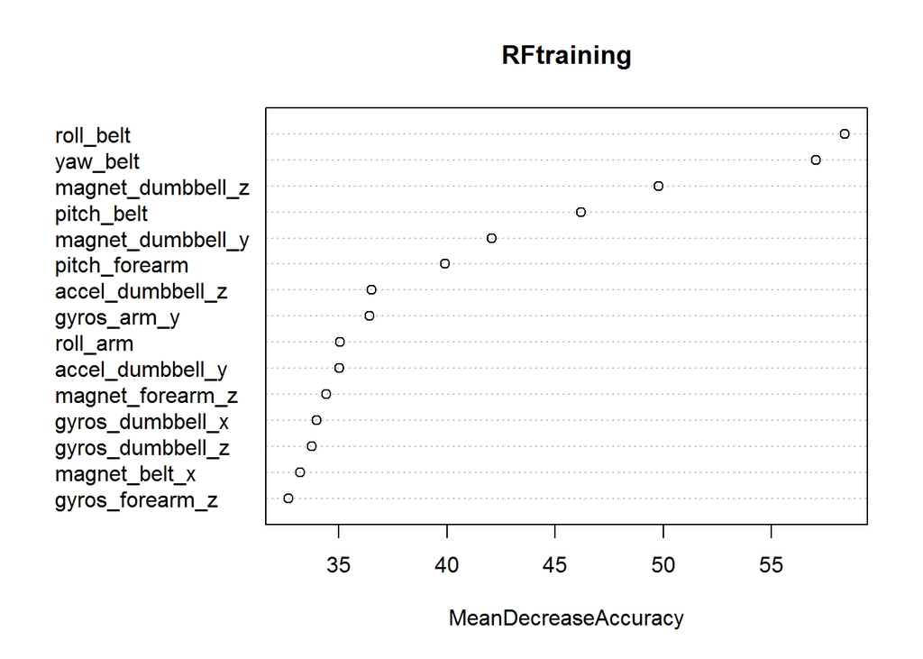

```r
# Plot variables of importance
varImpPlot(RFtraining, type=1, n.var=15)
```

The following plot illustrates how the error rate decreases with an increasing number of trees.

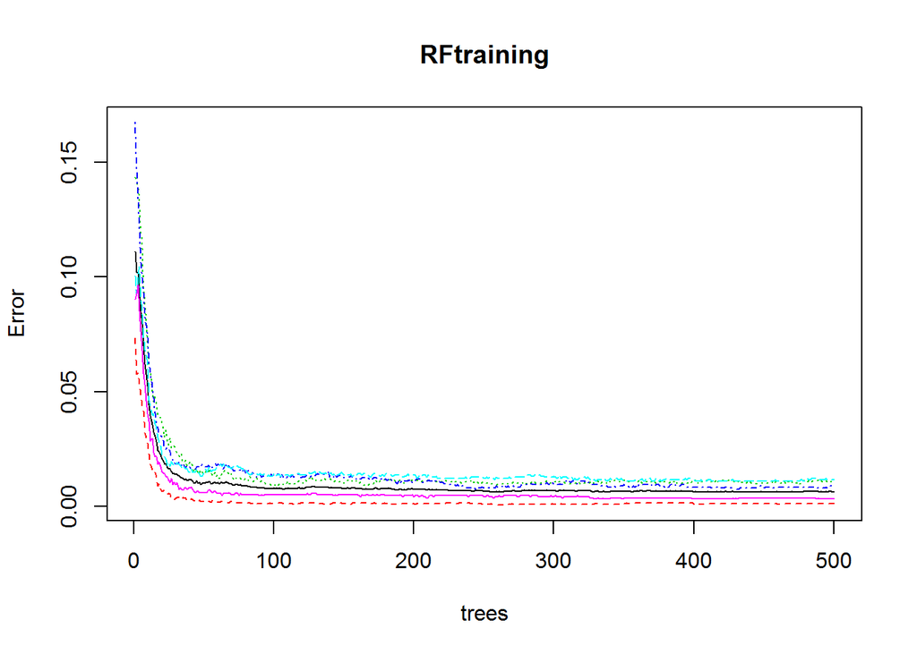

```r
# Plot error rate vs. number of trees
plot(RFtraining)
```

The error rate is very low for all classes. This will be confirmed in the next section.

# 4. In and Out Sample Errors

The model has been built on the training set. Therefore, we expect a low error rate if we apply the model to predict the values of the training set (in sample error).

```r
# in sample error rate
classe_predicted_training <- predict(RFtraining, trainingPML)
predictTraining <- data.frame(classe_predicted_training)
predictTraining$classe <- trainingPML$classe
predictTraining$success = (predictTraining$classe_predicted_training==predictTraining$classe)
summary(predictTraining)
```

```
##  classe_predicted_training classe   success
##  A:3283                    A:3283   Mode:logical
##  B:2231                    B:2231   TRUE:11532
##  C:2012                    C:2012   NA's:0
##  D:1889                    D:1889
##  E:2117                    E:2117
```

The model perfectly fits to the training set.

Now we check the *out of sample error*. For that purpose, we apply the model, which was derived using the 60% training sample, to the remaining 40% testing sample. This procedure is called cross validation.

```r
# out of sample error
classe_predicted_testing <- predict(RFtraining, testingPML)
predictTesting <- data.frame(classe_predicted_testing)
predictTesting$classe <- testingPML$classe
predictTesting$success <- (predictTesting$classe_predicted_testing==predictTesting$classe)
summary(predictTesting)
```

```
##  classe_predicted_testing classe    success
##  A:2197                   A:2188   Mode :logical
##  B:1489                   B:1487   FALSE:65
##  C:1347                   C:1340   TRUE :7619
##  D:1246                   D:1258   NA's :0
##  E:1405                   E:1411
```

Let’s calculate the error rate in percent:

```r
length(which(predictTesting$success == FALSE)) * 100 / length(predictTesting$success)
```

```
## [1] 0.8459
```

As can be seen from the summary, the out of sample error rate is low, i.e. the *Random Forrest* is a good prediction method for our data set.